# si544-day5-basic-regression

Drew Pappas

10/4/2019

```r
library(tidyverse)
library(moderndive)
library(skimr)
library(gapminder)
```

## Load & Look

```r
evals_ch6 <- evals %>%
  select(ID, score, bty_avg, age)
```

`glimpse` can be helpful:

```r
glimpse(evals_ch6)
```

```
## Observations: 463
## Variables: 4
## $ ID      <int> 1, 2, 3, 4, 5, 6, 7, 8, 9, 10, 11, 12, 13, 14, 15, 16, 1…
## $ score   <dbl> 4.7, 4.1, 3.9, 4.8, 4.6, 4.3, 2.8, 4.1, 3.4, 4.5, 3.8, 4…
## $ bty_avg <dbl> 5.000, 5.000, 5.000, 5.000, 3.000, 3.000, 3.000, 3.333, …
## $ age     <int> 36, 36, 36, 36, 59, 59, 59, 51, 51, 40, 40, 40, 40, 40, …
```

Alternatively, you can draw a random sample of some values and look at what you get:

```r
evals_ch6 %>% sample_n(5)
```

```
## # A tibble: 5 x 4
##      ID score bty_avg   age
##   <int> <dbl>   <dbl> <int>
## 1   209   4.8    3.67    60
## 2   407   3.8    2.83    57
## 3    72   3.9    4.83    42
## 4   430   4.5    5.83    33
## 5   395   4.2    3.33    45
```

Now that you understand descriptive statistics and visualizations, let’s take a shortcut:

```r
evals_ch6 %>%
  select(score, bty_avg) %>%
  skim()
```

```
## Skim summary statistics
##  n obs: 463
##  n variables: 2
##
## ── Variable type:numeric ──────────────────────────────────────────────────────────────────────────────
##  variable missing complete   n mean   sd   p0  p25  p50 p75 p100     hist
##   bty_avg       0      463 463 4.42 1.53 1.67 3.17 4.33 5.5 8.17 ▂▅▅▇▃▃▂▁
##     score       0      463 463 4.17 0.54 2.3  3.8  4.3  4.6 5    ▁▁▂▃▅▇▇▆
```

```r
evals_ch6 %>%
  get_correlation(formula = score ~ bty_avg)
```

```
## # A tibble: 1 x 1
##   correlation
##         <dbl>
## 1       0.187
```

Equivalently:

```r
evals_ch6 %>%
  summarize(correlation = cor(score, bty_avg))
```

```
## # A tibble: 1 x 1
##   correlation
##         <dbl>
## 1       0.187
```

Visualization:

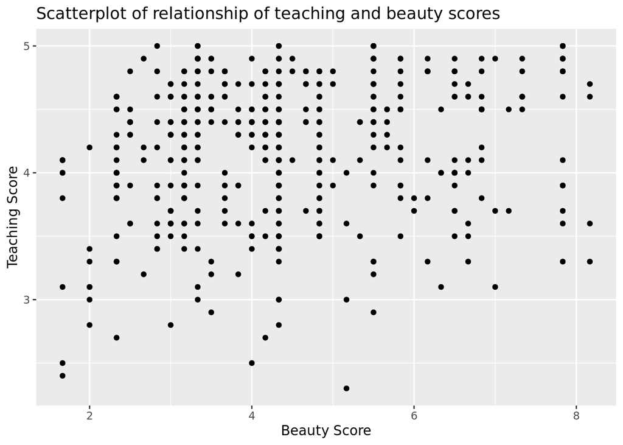

```r
ggplot(evals_ch6, aes(x = bty_avg, y = score)) +
  geom_point() +
  labs(x = "Beauty Score", y = "Teaching Score",
       title = "Scatterplot of relationship of teaching and beauty scores")
```

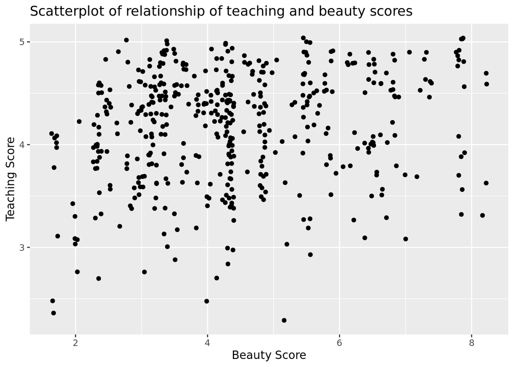

```r
ggplot(evals_ch6, aes(x = bty_avg, y = score)) +
  geom_jitter() +
  labs(x = "Beauty Score", y = "Teaching Score",
       title = "Scatterplot of relationship of teaching and beauty scores")
```

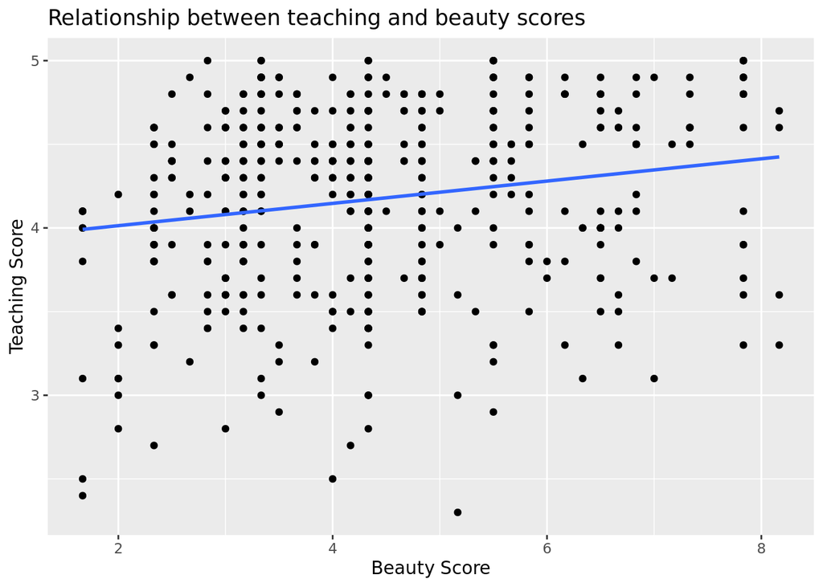

```r
ggplot(evals_ch6, aes(x = bty_avg, y = score)) +
  geom_point() +
  labs(x = "Beauty Score", y = "Teaching Score",
       title = "Relationship between teaching and beauty scores") +
  geom_smooth(method = "lm", se = FALSE)
```

### Learning Check 544.5.1

Repeat this for our handwriting data, looking at the relationship between dominant and non_dominant.

```r
load("handwriting2.Rdata")
```

1. Use glimpse() to get a “feel” for the handwriting data.

```r
glimpse(handwriting.data)
```

```
## Observations: 73
## Variables: 3
## $ dominant     <dbl> 4.13, 5.83, 7.01, 4.95, 3.97, 5.26, 3.68, 5.51, 3.5…
## $ non_dominant <dbl> 6.26, 14.30, 14.30, 8.02, 11.24, 11.40, 7.53, 15.38…
## $ n_letters    <int> 11, 11, 17, 7, 10, 10, 9, 15, 11, 13, 9, 13, 16, 16…
```

2. Use skim() to generate summary statistics for dominant and non-dominant times.

```r
handwriting.data %>%
  skim()
```

```
## Skim summary statistics
##  n obs: 73
##  n variables: 3
##
## ── Variable type:integer ──────────────────────────────────────────────────────────────────────────────
##   variable missing complete  n  mean   sd p0 p25 p50 p75 p100     hist
##  n_letters       0       73 73 11.15 3.08  4   9  11  13   18 ▁▁▃▇▁▅▂▁
##
## ── Variable type:numeric ──────────────────────────────────────────────────────────────────────────────
##      variable missing complete  n  mean   sd   p0  p25   p50   p75  p100
##      dominant       0       73 73  6.01 3.28 2.21 4.18  5.24  7.38 23.55
##  non_dominant       0       73 73 12.13 4.67 4.51 9.19 11.19 15.32 26.73
##      hist
##  ▇▇▂▁▁▁▁▁
##  ▃▇▅▅▃▁▁▁
```

3. Calculate the correlation coefficient for dominant and non-dominant times. What does that value tell you?

```r
handwriting.data %>%
  summarize(correlation = cor(dominant, non_dominant))
```

```
##   correlation
## 1   0.6824771
```

There is a moderate positive correlation between dominant and non-dominant times. As dominant times increase, so do non-dominant times.

4. Create a scatterplot with non-dominant on the y (vertical) axis and dominant on the x (horizontal) axis. Use R to draw a line through the data to show the relationship between dominant and non-dominant times.

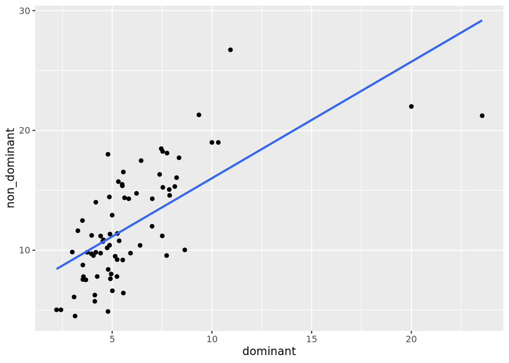

```r
ggplot(handwriting.data, aes(x  = dominant, y = non_dominant))+
  geom_point()+
  geom_smooth(method = "lm", se = FALSE)
```

## Simple Linear Regression

```r
# Fit regression model:
score_model <- lm(score ~ bty_avg, data = evals_ch6)
```

```r
# Get regression table:
get_regression_table(score_model)
```

```
## # A tibble: 2 x 7
##   term      estimate std_error statistic p_value lower_ci upper_ci
##   <chr>        <dbl>     <dbl>     <dbl>   <dbl>    <dbl>    <dbl>
## 1 intercept    3.88      0.076     51.0        0    3.73     4.03
## 2 bty_avg      0.067     0.016      4.09       0    0.035    0.099
```

```r
get_regression_summaries(score_model)
```

```
## # A tibble: 1 x 8
##   r_squared adj_r_squared   mse  rmse sigma statistic p_value    df
##       <dbl>         <dbl> <dbl> <dbl> <dbl>     <dbl>   <dbl> <dbl>
## 1     0.035         0.033 0.285 0.534 0.535      16.7       0     2
```

### Best fit

```r
regression_points <- get_regression_points(score_model)
regression_points
```

```
## # A tibble: 463 x 5
##       ID score bty_avg score_hat residual
##    <int> <dbl>   <dbl>     <dbl>    <dbl>
##  1     1   4.7    5         4.21    0.486
##  2     2   4.1    5         4.21   -0.114
##  3     3   3.9    5         4.21   -0.314
##  4     4   4.8    5         4.21    0.586
##  5     5   4.6    3         4.08    0.52
##  6     6   4.3    3         4.08    0.22
##  7     7   2.8    3         4.08   -1.28
##  8     8   4.1    3.33      4.10   -0.002
##  9     9   3.4    3.33      4.10   -0.702
## 10    10   4.5    3.17      4.09    0.409
## # … with 453 more rows
```

Let’s calculate the sum of squared residuals using a pipeline:

```r
regression_points %>%
  mutate(squared_residuals = residual^2) %>%
  summarize(sum_of_squared_residuals = sum(squared_residuals))
```

```
## # A tibble: 1 x 1
##   sum_of_squared_residuals
##                      <dbl>
## 1                     132.
```

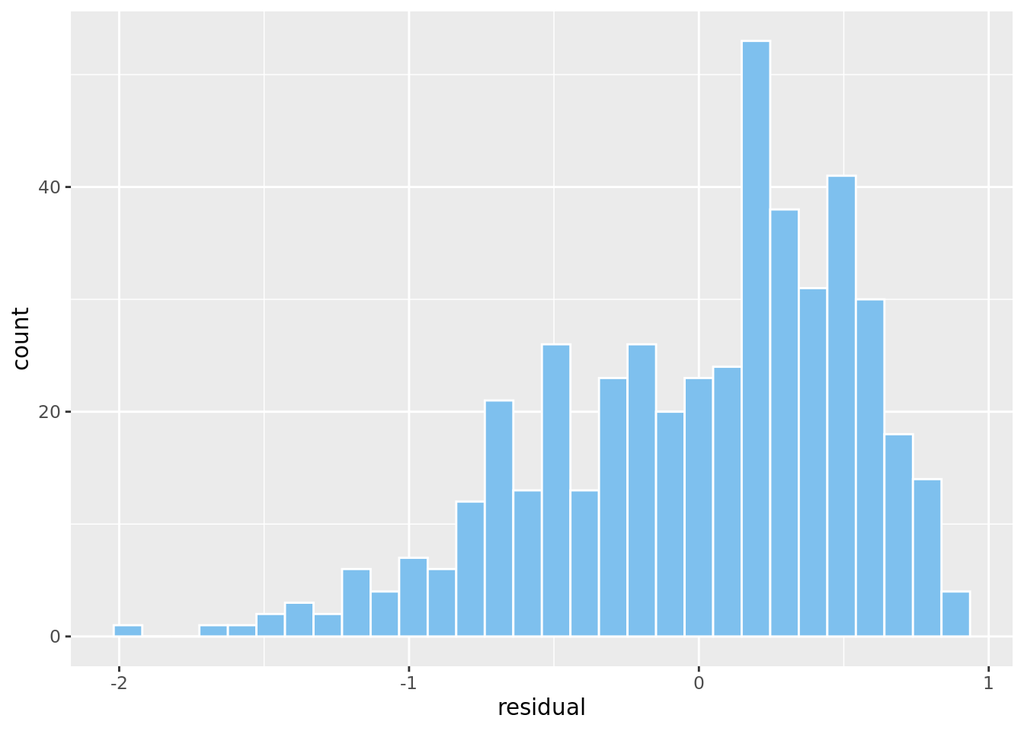

```r
ggplot(regression_points, mapping=aes(x=residual)) + geom_histogram( color = 'white', fill = 'skyblue2')
```

### Learning Check 544.5.2

Repeat the above steps with the handwriting data from discussion section:

1. Create a linear model (using the lm() function) to model non-dominant time as the outcome variable and dominant time as the explanatory one.

```r
handwriting.model <- lm(non_dominant ~ dominant, data = handwriting.data)
```

2. Use get_regression_table() to get the coefficients for the regression model.

```r
get_regression_table(handwriting.model)
```

```
## # A tibble: 2 x 7
##   term      estimate std_error statistic p_value lower_ci upper_ci
##   <chr>        <dbl>     <dbl>     <dbl>   <dbl>    <dbl>    <dbl>
## 1 intercept    6.29      0.845      7.44       0    4.60      7.97
## 2 dominant     0.973     0.124      7.87       0    0.726     1.22
```

3. What would the expected value of non-dominant time be for a name that took 6 seconds to write with one’s dominant hand?

non_dominant time = 6.286 + 0.973 * 6 = 12.124 is the expected value for the non-dominant hand given that it took 6 seconds for the dominant hand.

4. Use get_regression_summaries() to get information about how “good” the model is. Comment on how much variance is explained by the model. What’s the average deviation from the predicted value?

```r
# INSERT YOUR CODE HERE
get_regression_summaries(handwriting.model)
```

```
## # A tibble: 1 x 8
##   r_squared adj_r_squared   mse  rmse sigma statistic p_value    df
##       <dbl>         <dbl> <dbl> <dbl> <dbl>     <dbl>   <dbl> <dbl>
## 1     0.466         0.458  11.5  3.39  3.44      61.9       0     2
```

This model explains less than half of the variance of the data points. With an r_squared of 0.46, there is still a lot of variance unexplained. Additioinally, on average the model will deviate from the predicted value by 3.4 seconds (rmse).

5. Identify the two most extreme residual values. What do those values mean? Can you infer anything about the individuals with those values?

```r
# INSERT YOUR R CODE HERE
get_regression_points(handwriting.model) %>% arrange(desc(residual))
```

```
## # A tibble: 73 x 5
##       ID non_dominant dominant non_dominant_hat residual
##    <int>        <dbl>    <dbl>            <dbl>    <dbl>
##  1    56         26.7    10.9              16.9     9.81
##  2    17         18.0     4.79             10.9     7.06
##  3    71         21.3     9.35             15.4     5.92
##  4    13         18.5     7.46             13.5     4.94
##  5    57         17.5     6.45             12.6     4.92
##  6    47         16.5     5.56             11.7     4.84
##  7    55         18.2     7.53             13.6     4.64
##  8    33         18.1     7.75             13.8     4.29
##  9    10         15.7     5.31             11.5     4.28
## 10    72         15.5     5.5              11.6     3.86
## # … with 63 more rows
```

```r
get_regression_points(handwriting.model) %>% arrange(residual)
```

```
## # A tibble: 73 x 5
##       ID non_dominant dominant non_dominant_hat residual
##    <int>        <dbl>    <dbl>            <dbl>    <dbl>
##  1    50        21.2     23.6             29.2     -7.96
##  2    67         4.89     4.79            10.9     -6.06
##  3    54         6.43     5.56            11.7     -5.26
##  4    30         4.51     3.14             9.34    -4.83
##  5    51        10.0      8.64            14.7     -4.66
##  6    53         5.74     4.13            10.3     -4.56
##  7    52         6.62     5.01            11.2     -4.54
##  8    40         9.56     7.73            13.8     -4.24
##  9     1         6.26     4.13            10.3     -4.04
## 10    65        22       20               25.7     -3.74
## # … with 63 more rows
```

The two most extreme residuals come from ID 50 and ID 56. Those residuals are -7.962 and 9.813 respectively. For the positive residual of 9.813, the predicted time was 16.92 seconds for their non-dominant hand. Meaning, they took significantly longer than expected. For the negative residual of -7.962, their predicted time for their non-dominant hand was 29.19 seconds. They were much faster than anticipated.

Looking at each of these values there might be some inferences that can be drawn. For the positive residual, a possible explanation is that they had difficulties in getting their writing utensil to work for their non-dominant hand, and thus the time was longer than anticipated. For the negative residual, possible explanations are that the respondent is ambidextrous or that they have a short name.

## One categorical predictor variable

Let’s return to the Gapminder data:

```r
library(gapminder)
gapminder2007 <- gapminder %>%
  filter(year == 2007) %>%
  select(country, lifeExp, continent, gdpPercap)
```

### Learning Check 544.5.3

What did the above code block do?

```r
glimpse(gapminder2007)
```

```
## Observations: 142
## Variables: 4
## $ country   <fct> Afghanistan, Albania, Algeria, Angola, Argentina, Aust…
## $ lifeExp   <dbl> 43.828, 76.423, 72.301, 42.731, 75.320, 81.235, 79.829…
## $ continent <fct> Asia, Europe, Africa, Africa, Americas, Oceania, Europ…
## $ gdpPercap <dbl> 974.5803, 5937.0295, 6223.3675, 4797.2313, 12779.3796,…
```